# PBMC Cluster9

RG

2023-06-13

## The plot of PC4 vs PC1 …

- suggests that PC4 might be two groups
- if it consists of two sub-groups then if we compute distances between all pairs of points we should have some sort of multi-modal distribution
- here we are going to use the isolation forest approach

## Let’s use isolation forests to see if we can better understand cluster 9

```r
rS = apply(exprs9, 1, function(x) sum(x==0))
exprs9a = exprs9[rS<100,]
iF = isolation.forest(t(exprs9a))
preds=predict(iF, t(exprs9a))
```

## And …

- we see a bimodal distribution suggesting that there are two types of points in this cluster
- just as we had seen in our previous analysis

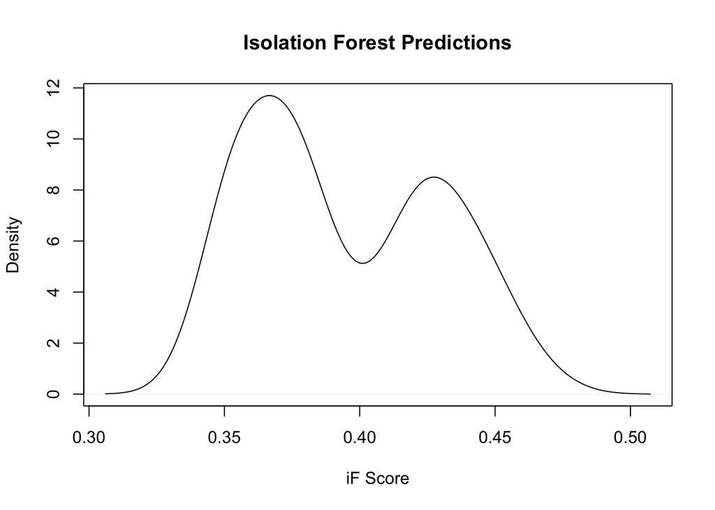

## Do we have outliers?

- the basic advice is that an outlier has values close to 1

```r
summary(preds)
```

```
##    Min. 1st Qu.  Median    Mean 3rd Qu.    Max.
##  0.3429  0.3649  0.3830  0.3946  0.4247  0.4705
```

- the values are all less than 1/2 - so no outliers seem to be present

## Other things we could do…

- build an isolation forest for all the data in the PBMC data set
- compute predictions for all of the cells
- look at boxplots of the predictions for each cluster (or maybe stacked density plots)
- are the proposed clusters homogeneous with respect to the isolation forest notion of distance